# Nuclear weapons devolopment over time

Olivia Englund Kusk, Natasha Marie Hauberg Due, Simone Bærnthsen

2026-05-28

```r
knitr::opts_chunk$set(echo = TRUE)
```

### Explore Nuclear Weapons’ stockpile over time

We want to use ggplot to investigate how the development of Nuclear Weapons’ stockpile in Russia and the US over the period from 1945-2024.

```r
#running of needed library
library(tidyverse)
```

```r
library(ggplot2)
library(here)
#getting the data
NW_stockpiles <- read_csv("data/NW_stockpile.csv")
```

### Check data and renaming columns

We are going to check if the data is correctly loaded and if anythings need to be changed to make it easier to work with, and renaming column 1 from “Entity” to “Country” and column 4 from “Number of nuclear warheads” to “Number_of_NW”.

```r
#Renaming columns
names(NW_stockpiles)[1]<-"Country"
names(NW_stockpiles)[4]<-"Number_of_NW"

#Check the data
str(NW_stockpiles)
```

```
## spc_tbl_ [880 × 4] (S3: spec_tbl_df/tbl_df/tbl/data.frame)
##  $ Country     : chr [1:880] "China" "China" "China" "China" ...
##  $ Code        : chr [1:880] "CHN" "CHN" "CHN" "CHN" ...
##  $ Year        : num [1:880] 1945 1946 1947 1948 1949 ...
##  $ Number_of_NW: num [1:880] 0 0 0 0 0 0 0 0 0 0 ...
##  - attr(*, "spec")=
##   .. cols(
##   ..   Entity = col_character(),
##   ..   Code = col_character(),
##   ..   Year = col_double(),
##   ..   `Number of nuclear warheads` = col_double()
##   .. )
##  - attr(*, "problems")=<externalptr>
```

```r
unique(NW_stockpiles$Country)
```

```
##  [1] "China"          "France"         "India"          "Israel"
##  [5] "North Korea"    "Pakistan"       "Russia"         "South Africa"
##  [9] "United Kingdom" "United States"  "World"
```

```r
first(NW_stockpiles$Year)
```

```
## [1] 1945
```

```r
glimpse(NW_stockpiles)
```

```
## Rows: 880
## Columns: 4
## $ Country      <chr> "China", "China", "China", "China", "China", "China", "Ch…
## $ Code         <chr> "CHN", "CHN", "CHN", "CHN", "CHN", "CHN", "CHN", "CHN", "…
## $ Year         <dbl> 1945, 1946, 1947, 1948, 1949, 1950, 1951, 1952, 1953, 195…
## $ Number_of_NW <dbl> 0, 0, 0, 0, 0, 0, 0, 0, 0, 0, 0, 0, 0, 0, 0, 0, 0, 0, 0, …
```

### Plotting of the nuclear warhead stockpiles

We are going to create an graph that compare all of the countries with nuclear warheads and the whole world.

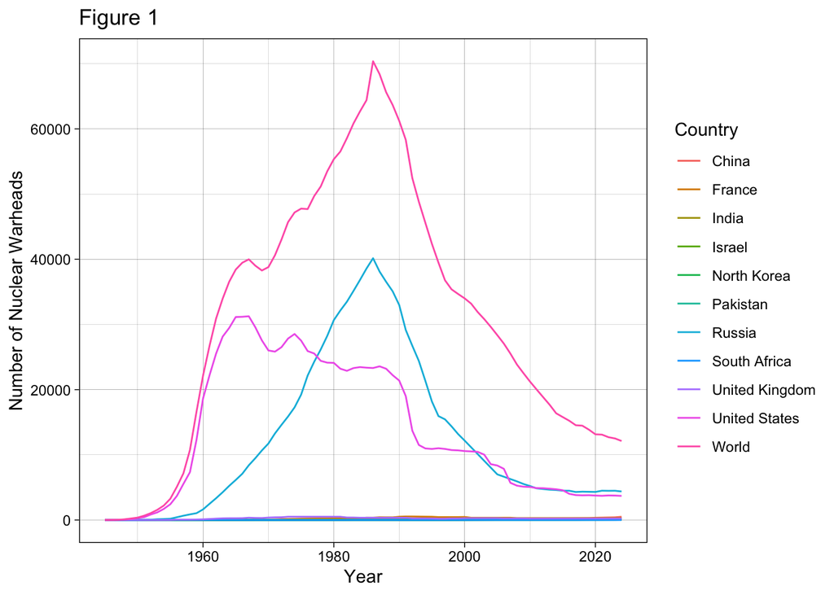

```r
Nw_stockpiles <- NW_stockpiles %>%
  ggplot(aes(x=Year,y=Number_of_NW, colour = Country))+
  geom_line()+
  theme_linedraw()+
  labs(title = "Figure 1",
       y="Number of Nuclear Warheads")
Nw_stockpiles
```

```r
ggsave(here("figures","nw_all.png"), plot = Nw_stockpiles, height = 5)
```

### Plotting of the nuclear warhead stockpiles

To better understand the individual among of nuclear warheads pr country and the world, we will also splitting them into individual graphs.

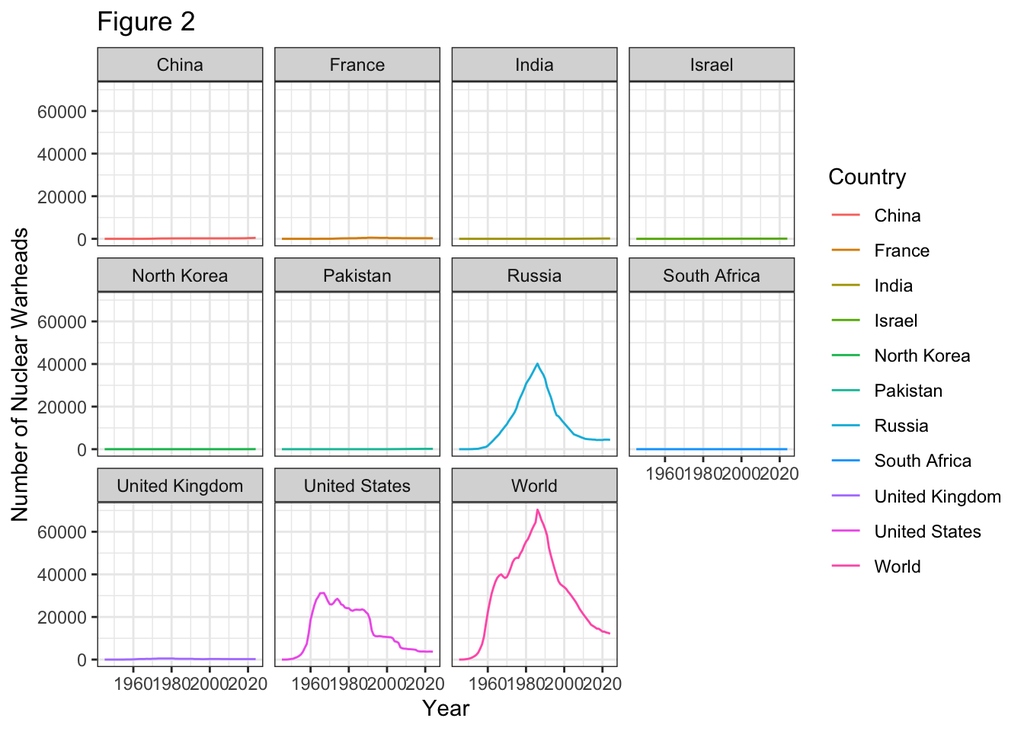

```r
Nw_individual <- NW_stockpiles %>%
  ggplot(aes(x=Year,y=Number_of_NW, colour = Country))+
  geom_line()+
  theme_bw()+
  facet_wrap(~Country)+
  labs(title = "Figure 2",
       y="Number of Nuclear Warheads")

Nw_individual
```

```r
ggsave(here("figures","nw_all_individual.png"), plot = Nw_individual, height = 5)
```

### Creating a dataset without Russia and the US

Because Russia and the US (and the whole world) have a lot more nuclear warheads than the rest of the countries, will we create a new dataset without Russia, the US and the World.

```r
Without_Rus_US <- NW_stockpiles %>%
  filter(Country!="Russia") %>%
  filter(Country!="United States") %>%
  filter(Country!="World")
```

### Plotting of the nuclear warhead stockpiles

We are going to create an graph that compare the countries with nuclear warheads after removing Russia, the US and the World.

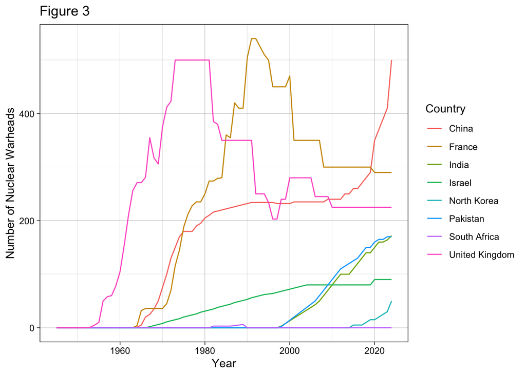

```r
Graph_W_Rus_US <- Without_Rus_US %>%
   ggplot(aes(x=Year,y=Number_of_NW, colour = Country))+
  geom_line()+
  theme_linedraw()+
  labs(title = "Figure 3",
       y="Number of Nuclear Warheads")

Graph_W_Rus_US
```

```r
ggsave(here("figures","nw_without_rus_us.png"), plot = Graph_W_Rus_US, height = 5)
```

### Plotting of the nuclear warhead stockpiles individual

Once again we are splitting the individual graphs to better see the individual countries data.

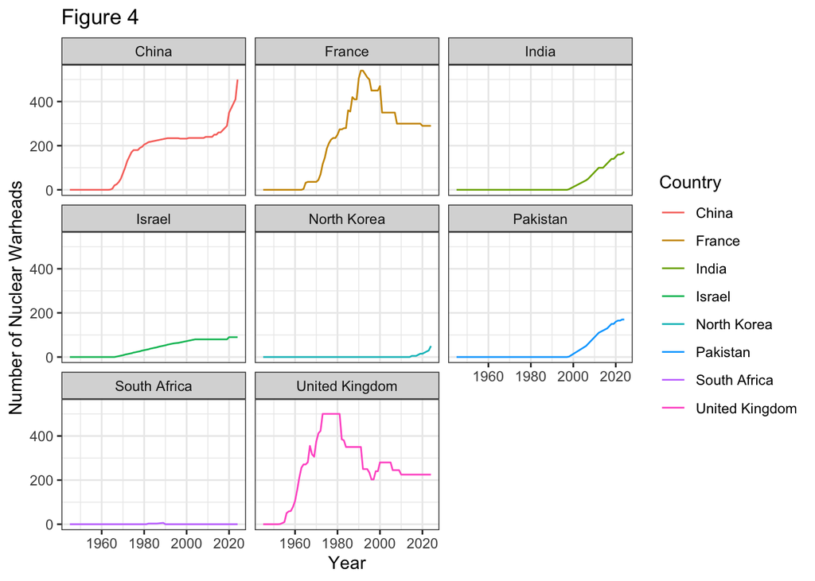

```r
Graph_W_Rus_US_indi <- Without_Rus_US %>%
  ggplot(aes(x=Year,y=Number_of_NW, colour = Country))+
  geom_line()+
  theme_bw()+
  facet_wrap(~Country)+
  labs(title = "Figure 4",
       y="Number of Nuclear Warheads")

Graph_W_Rus_US_indi
```

```r
ggsave(here("figures","nw_w_rus_us_indi.png"), plot = Graph_W_Rus_US_indi, height = 5)
```

### Creating a dataset only with Russia and the US

We will also create a dataset only with Russia and the US.

```r
Only_Rus_US <- NW_stockpiles %>%
  filter(Country =="Russia"|Country=="United States")
```

### Plotting of the nuclear warhead stockpiles

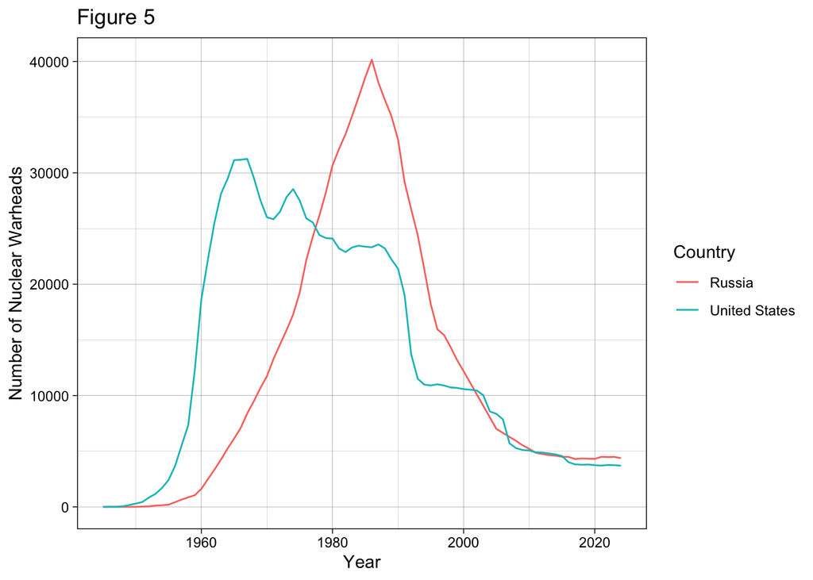

```r
Graph_Rus_Us <- Only_Rus_US %>%
  ggplot(aes(x=Year,y=Number_of_NW, colour = Country))+
  geom_line()+
  theme_linedraw()+
  labs(title = "Figure 5",
       y="Number of Nuclear Warheads")

Graph_Rus_Us
```

```r
ggsave(here("figures","nw_rus_us.png"), plot = Graph_Rus_Us, height = 5)
```

Here will we split Russia and the US into individual graphs to better understand the countries data.

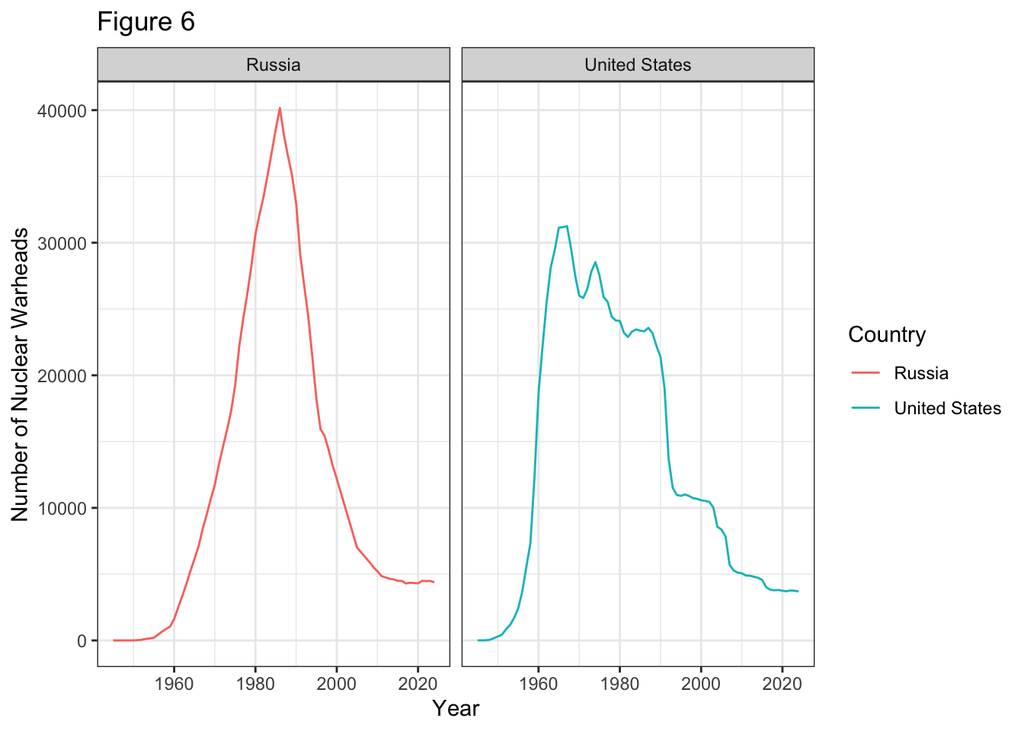

```r
Graph_Rus_Us_indi <- Only_Rus_US %>%
  ggplot(aes(x=Year,y=Number_of_NW, colour = Country))+
  geom_line()+
  theme_bw()+
  facet_wrap(~Country)+
  labs(title = "Figure 6",
       y="Number of Nuclear Warheads")

Graph_Rus_Us_indi
```

```r
ggsave(here("figures","nw_rus_us_indi.png"), plot = Graph_Rus_Us_indi, height = 3, width = 6)
```